# SEER Early Mortality Logistic Regression

Hajin Jang

3/17/2024

### This project applies logistic regression to SEER cancer registry data to evaluate risk factors for early mortality, integrating contingency tables, model-based odds ratios, diagnostics, and model fit assessment.

```r
library(tidyverse)
library(here)
library(lmtest)
library(glmtoolbox)
library(car)
library(performance)
```

## 0. Loading the data

The following data come from the SEER cancer registry. We are interested in studying early mortality (defined as death within 2 months of cancer diagnosis) and potential risk factors.

```r
# read in data
seer <- read_csv("seer2016.csv") %>%
  mutate(race = factor(race, levels= c(0,1,2,3,99),
                       labels = c("White","Black", "American Indian/Alaska Native","Asian or Pacific Islander", "Unknown")),
         sex = factor(sex, levels = c(0,1),
                      labels = c("Male","Female")))
# drop missing values
seer <- seer %>%
  filter(!is.na(cat_res) & !is.na(income_cat))
```

## 1. Contingency table

**A contingency table showing the breakdown of early mortality by primary cancer site**

```r
# table of counts
xtabs(~ grouped_primary + early_mortality, data = seer)
```

```
##                    early_mortality
## grouped_primary        0    1
##   Bladder             45    9
##   Breast             290   19
##   CRC                372   61
##   Gastro-esophageal  231   59
##   HCC                 32   18
##   Head and Neck      104    4
##   Kidney             129   17
##   Lung              1266  405
##   Melanoma            51   11
##   Other              227   37
##   Ovary              124   17
##   Pancreato-biliary  366  152
##   Prostate           291   10
```

```r
# table of proportions by cancer site
xtabs(~ grouped_primary + early_mortality, data = seer) %>% prop.table(margin=1)
```

```
##                    early_mortality
## grouped_primary              0          1
##   Bladder           0.83333333 0.16666667
##   Breast            0.93851133 0.06148867
##   CRC               0.85912240 0.14087760
##   Gastro-esophageal 0.79655172 0.20344828
##   HCC               0.64000000 0.36000000
##   Head and Neck     0.96296296 0.03703704
##   Kidney            0.88356164 0.11643836
##   Lung              0.75763016 0.24236984
##   Melanoma          0.82258065 0.17741935
##   Other             0.85984848 0.14015152
##   Ovary             0.87943262 0.12056738
##   Pancreato-biliary 0.70656371 0.29343629
##   Prostate          0.96677741 0.03322259
```

## 2. Odds and odds ratios (table based)

**Using this table I calculated the odds of early mortality for people with bladder cancer, the odds of early mortality for people with breast cancer, and the odds ratio for early mortality comparing breast cancer to bladder cancer.**

```r
# odds for bladder cancer
odds_bladder = 0.167/0.833
odds_bladder
```

```
## [1] 0.2004802
```

```r
# odds for breast cancer
odds_breast = 0.061/0.939
odds_breast
```

```
## [1] 0.06496273
```

```r
# odds ratio
odds_breast/odds_bladder
```

```
## [1] 0.3240356
```

**Comment:**

- Odds for breast cancer: 0.065
- Odds for bladder cancer: 0.200

**Odds ratio:** 0.324

People with bladder cancer have the higher odds of early mortality.

## 3. Logistic regression model (single predictor)

**Fitting a logistic regression model using primary cancer site (grouped_primary) as the sole predictor.**

```r
# fit logistic regression model
fit <- glm(early_mortality ~ grouped_primary, data = seer, family = binomial(link = "logit"))

# print output
summary(fit)
```

```
##
## Call:
## glm(formula = early_mortality ~ grouped_primary, family = binomial(link = "logit"),
##     data = seer)
##
## Coefficients:
##                                  Estimate Std. Error z value Pr(>|z|)
## (Intercept)                      -1.60944    0.36515  -4.408 1.05e-05 ***
## grouped_primaryBreast            -1.11600    0.43522  -2.564 0.010340 *
## grouped_primaryCRC               -0.19858    0.39040  -0.509 0.610992
## grouped_primaryGastro-esophageal  0.24456    0.39321   0.622 0.533970
## grouped_primaryHCC                1.03407    0.46919   2.204 0.027527 *
## grouped_primaryHead and Neck     -1.64866    0.62668  -2.631 0.008519 **
## grouped_primaryKidney            -0.41716    0.44711  -0.933 0.350813
## grouped_primaryLung               0.46971    0.36958   1.271 0.203761
## grouped_primaryMelanoma           0.07551    0.49381   0.153 0.878471
## grouped_primaryOther             -0.20459    0.40591  -0.504 0.614237
## grouped_primaryOvary             -0.37763    0.44746  -0.844 0.398703
## grouped_primaryPancreato-biliary  0.73069    0.37768   1.935 0.053033 .
## grouped_primaryProstate          -1.76130    0.48642  -3.621 0.000294 ***
## ---
## Signif. codes:  0 '***' 0.001 '**' 0.01 '*' 0.05 '.' 0.1 ' ' 1
##
## (Dispersion parameter for binomial family taken to be 1)
##
##     Null deviance: 4207.1  on 4346  degrees of freedom
## Residual deviance: 3982.4  on 4334  degrees of freedom
## AIC: 4008.4
##
## Number of Fisher Scoring iterations: 5
```

**Interpretation:** Intercept: When the primary cancer site is bladder cancer, the log odds of early mortality is -1.609. Coefficient for breast cancer: The log odds of early mortality decreases by 1.116 compared to when it’s bladder cancer.

## 4. Odds and odds ratios (model based)

**Based on the model above, I estimated the odds of early mortality for people with bladder cancer, for people with breast cancer, and the odds ratio for early mortality comparing breast cancer to bladder cancer.**

```r
# odds for bladder cancer
odds_bladder <- exp(-1.60944)

# odds for breast cancer
odds_breast <- exp(-1.60944 - 1.11600)

# odds ratio
odds_ratio <- odds_breast / odds_bladder
```

**Comment:**

**Odds ratio:** 0.328

The result is the same with the answer I got in part 2.

## 5. Logistic regression model (multiple predictors)

**Adding sex, race, age, residency category, and income category to the model.**

```r
# fit model
fit2 <- glm(early_mortality ~ grouped_primary + sex + race + age + cat_res + income_cat, data = seer, family = binomial(link = "logit"))

# print model output
summary(fit2)
```

```
##
## Call:
## glm(formula = early_mortality ~ grouped_primary + sex + race +
##     age + cat_res + income_cat, family = binomial(link = "logit"),
##     data = seer)
##
## Coefficients:
##                                     Estimate Std. Error z value Pr(>|z|)
## (Intercept)                       -3.7814261  0.4379817  -8.634  < 2e-16 ***
## grouped_primaryBreast             -0.7973994  0.4434895  -1.798 0.072175 .
## grouped_primaryCRC                -0.0101702  0.3955682  -0.026 0.979488
## grouped_primaryGastro-esophageal   0.4327646  0.3988896   1.085 0.277956
## grouped_primaryHCC                 1.2098206  0.4757884   2.543 0.010998 *
## grouped_primaryHead and Neck      -1.4748772  0.6314782  -2.336 0.019512 *
## grouped_primaryKidney             -0.2208500  0.4528465  -0.488 0.625767
## grouped_primaryLung                0.5689150  0.3742895   1.520 0.128514
## grouped_primaryMelanoma            0.3314445  0.5019698   0.660 0.509069
## grouped_primaryOther               0.1319025  0.4129427   0.319 0.749407
## grouped_primaryOvary              -0.1486852  0.4561299  -0.326 0.744446
## grouped_primaryPancreato-biliary   0.8948446  0.3829212   2.337 0.019445 *
## grouped_primaryProstate           -1.8485896  0.4918612  -3.758 0.000171 ***
## sexFemale                         -0.1966828  0.0858772  -2.290 0.022005 *
## raceBlack                          0.0640932  0.1222530   0.524 0.600093
## raceAmerican Indian/Alaska Native  0.1410459  0.4577404   0.308 0.757979
## raceAsian or Pacific Islander     -0.1359981  0.1580868  -0.860 0.389637
## raceUnknown                        0.1520414  0.6051627   0.251 0.801628
## age                                0.0285330  0.0030146   9.465  < 2e-16 ***
## cat_resRural                       0.1131781  0.1968538   0.575 0.565335
## cat_resUrban                      -0.0004442  0.0885952  -0.005 0.995999
## income_catBelow 65K                0.2879207  0.0870399   3.308 0.000940 ***
## ---
## Signif. codes:  0 '***' 0.001 '**' 0.01 '*' 0.05 '.' 0.1 ' ' 1
##
## (Dispersion parameter for binomial family taken to be 1)
##
##     Null deviance: 4207.1  on 4346  degrees of freedom
## Residual deviance: 3876.3  on 4325  degrees of freedom
## AIC: 3920.3
##
## Number of Fisher Scoring iterations: 6
```

## 6. Interpret coefficients

**Interpretion of the intercept and the coefficient associated with primary breast cancer (grouped_primary = breast) in this model (from part 5).**

Intercept: The log odds of early mortality is -3.78 when the primary cancer site is bladder cancer, sex is male, race is white, age is 0, residency category is metropolitan, and income category is above 65K.

Coefficient for breast cancer: The difference in log odds is -0.797 if parient has breast cancer, holding all others constant. To be specific, the coefficient (-0.797) associated with primary breast cancer represents the change in log odds of early mortality when the primary cancer site changes from the reference category (bladder cancer) to breast cancer, holding all other variables constant.

## 7. Predicted value

**Example estimation of the probability of early mortality for a person with primary lung cancer who is male, Black, 60 years old, lives in an Urban area, and makes at least $65k a year.**

```r
intercept <- -3.7814261
coefficient_lung <- 0.5689150
coefficient_male <- 0
coefficient_black <- 0.0640932
coefficient_age <- 60 * 0.0285330
coefficient_urban <- -0.0004442
coefficient_above_65k <- 0

log_odds <- intercept +
            coefficient_lung +
            coefficient_male +
            coefficient_black +
            coefficient_age +
            coefficient_urban +
            coefficient_above_65k

# calculate predicted probability
probability <- exp(log_odds) / (1 + exp(log_odds))
probability
```

```
## [1] 0.1920286
```

## 8. Confidence intervals

**Constructing 95% confidence intervals on the log-odds scale and on the odds scale for all coefficients in the model (from part 5).**

```r
# log scale
confint(fit2)
```

```
##                                         2.5 %      97.5 %
## (Intercept)                       -4.68947261 -2.95967134
## grouped_primaryBreast             -1.64509219  0.11144549
## grouped_primaryCRC                -0.74519953  0.82198803
## grouped_primaryGastro-esophageal  -0.30940903  1.27058805
## grouped_primaryHCC                 0.29814999  2.17860033
## grouped_primaryHead and Neck      -2.82960323 -0.28944859
## grouped_primaryKidney             -1.09027443  0.70333647
## grouped_primaryLung               -0.11807211  1.36625210
## grouped_primaryMelanoma           -0.65244305  1.33650039
## grouped_primaryOther              -0.64263519  0.99248804
## grouped_primaryOvary              -1.02487609  0.78128114
## grouped_primaryPancreato-biliary   0.18870221  1.70646839
## grouped_primaryProstate           -2.82005233 -0.86653515
## sexFemale                         -0.36538996 -0.02866832
## raceBlack                         -0.17907028  0.30056012
## raceAmerican Indian/Alaska Native -0.82699755  0.99340779
## raceAsian or Pacific Islander     -0.45385697  0.16687538
## raceUnknown                       -1.16823225  1.26135691
## age                                0.02264138  0.03446203
## cat_resRural                      -0.28235633  0.49099430
## cat_resUrban                      -0.17481621  0.17257428
## income_catBelow 65K                0.11772828  0.45901341
```

```r
# odds scale
confint(fit2) %>% exp()
```

```
##                                         2.5 %     97.5 %
## (Intercept)                       0.009191532 0.05183595
## grouped_primaryBreast             0.192994770 1.11789280
## grouped_primaryCRC                0.474639586 2.27501815
## grouped_primaryGastro-esophageal  0.733880532 3.56294712
## grouped_primaryHCC                1.347363868 8.83393299
## grouped_primaryHead and Neck      0.059036273 0.74867628
## grouped_primaryKidney             0.336124239 2.02048276
## grouped_primaryLung               0.888631971 3.92062900
## grouped_primaryMelanoma           0.520771951 3.80570171
## grouped_primaryOther              0.525904740 2.69793872
## grouped_primaryOvary              0.358840925 2.18426882
## grouped_primaryPancreato-biliary  1.207681260 5.50946977
## grouped_primaryProstate           0.059602823 0.42040567
## sexFemale                         0.693925997 0.97173872
## raceBlack                         0.836047138 1.35061510
## raceAmerican Indian/Alaska Native 0.437360471 2.70042127
## raceAsian or Pacific Islander     0.635173575 1.18160701
## raceUnknown                       0.310916077 3.53020841
## age                               1.022899645 1.03506273
## cat_resRural                      0.754004963 1.63394005
## cat_resUrban                      0.839611317 1.18836008
## income_catBelow 65K               1.124938404 1.58251192
```

## 9. Interactions

**Adding an interaction between sex and income category.**

```r
# fit model with interaction
fit_int <- glm(early_mortality ~ grouped_primary + sex + race + age + cat_res + income_cat + sex*income_cat, data = seer, family = binomial(link = "logit"))

# Show the model output
summary(fit_int)
```

```
##
## Call:
## glm(formula = early_mortality ~ grouped_primary + sex + race +
##     age + cat_res + income_cat + sex * income_cat, family = binomial(link = "logit"),
##     data = seer)
##
## Coefficients:
##                                     Estimate Std. Error z value Pr(>|z|)
## (Intercept)                       -3.7535036  0.4395644  -8.539  < 2e-16 ***
## grouped_primaryBreast             -0.7977058  0.4435640  -1.798  0.07211 .
## grouped_primaryCRC                -0.0092945  0.3956394  -0.023  0.98126
## grouped_primaryGastro-esophageal   0.4294367  0.3989848   1.076  0.28178
## grouped_primaryHCC                 1.2087584  0.4757894   2.541  0.01107 *
## grouped_primaryHead and Neck      -1.4751951  0.6314883  -2.336  0.01949 *
## grouped_primaryKidney             -0.2173111  0.4529029  -0.480  0.63136
## grouped_primaryLung                0.5690956  0.3743598   1.520  0.12846
## grouped_primaryMelanoma            0.3279604  0.5019680   0.653  0.51353
## grouped_primaryOther               0.1295786  0.4130313   0.314  0.75373
## grouped_primaryOvary              -0.1537206  0.4563549  -0.337  0.73623
## grouped_primaryPancreato-biliary   0.8946439  0.3829881   2.336  0.01949 *
## grouped_primaryProstate           -1.8496605  0.4919001  -3.760  0.00017 ***
## sexFemale                         -0.2666371  0.1291131  -2.065  0.03891 *
## raceBlack                          0.0650032  0.1222541   0.532  0.59493
## raceAmerican Indian/Alaska Native  0.1477362  0.4575425   0.323  0.74678
## raceAsian or Pacific Islander     -0.1347288  0.1581141  -0.852  0.39416
## raceUnknown                        0.1422528  0.6051042   0.235  0.81414
## age                                0.0286175  0.0030171   9.485  < 2e-16 ***
## cat_resRural                       0.1147570  0.1968241   0.583  0.55986
## cat_resUrban                       0.0006924  0.0886018   0.008  0.99376
## income_catBelow 65K                0.2310131  0.1169169   1.976  0.04817 *
## sexFemale:income_catBelow 65K      0.1193550  0.1643569   0.726  0.46772
## ---
## Signif. codes:  0 '***' 0.001 '**' 0.01 '*' 0.05 '.' 0.1 ' ' 1
##
## (Dispersion parameter for binomial family taken to be 1)
##
##     Null deviance: 4207.1  on 4346  degrees of freedom
## Residual deviance: 3875.8  on 4324  degrees of freedom
## AIC: 3921.8
##
## Number of Fisher Scoring iterations: 6
```

## 10. Hypothesis Tests

**Testing for effect modification of income by sex (the interaction specified above) using the Wald test statistic and likelihood ratio test.**

```r
# likelihood ratio test
lrtest(fit2, fit_int)
```

|  | #Df | LogLik | Df | Chisq | Pr(>Chisq) |
| --- | --- | --- | --- | --- | --- |
| 1 | 22 | -1938.161 | NA | NA | NA |
| 2 | 23 | -1937.897 | 1 | 0.5275085 | 0.4676562 |

```r
# wald test
waldtest(fit2, fit_int, test="Chisq")
```

|  | Res.Df | Df | Chisq | Pr(>Chisq) |
| --- | --- | --- | --- | --- |
| 1 | 4325 | NA | NA | NA |
| 2 | 4324 | 1 | 0.5273572 | 0.4677201 |

**Interpretation:** * Likelihood Ratio Test: The interaction term does not significantly improve the model fit (p=0.4677). We fail to reject the null hypothesis that the model without the interaction term fits the data as well as the model with the interaction term.

- Wald Test: There is no evidence to support the presence of effect modification. We fail to reject the null hypothesis that the interaction term is equal to zero (p=0.4677).

## 11. Comparing Model Fit Metrics

**Comparing the deviance-based adjusted R-squared, deviance, AIC, and BIC values for each of the three models.**

```r
# metrics of model fit
# deviance-based adjusted R2
adjR2(fit) ; adjR2(fit2) ; adjR2(fit_int)
```

```
## [1] 0.05079
```

```
## [1] 0.07414
```

```
## [1] 0.07405
```

```r
# deviance
fit$deviance ; fit2$deviance ; fit_int$deviance
```

```
## [1] 3982.367
```

```
## [1] 3876.322
```

```
## [1] 3875.794
```

```r
# AIC
AIC(fit) ; AIC(fit2) ; AIC(fit_int)
```

```
## [1] 4008.367
```

```
## [1] 3920.322
```

```
## [1] 3921.794
```

```r
# BIC
BIC(fit) ; BIC(fit2) ; BIC(fit_int)
```

```
## [1] 4091.271
```

```
## [1] 4060.621
```

```
## [1] 4068.471
```

## 12. Collinearity

**Checking for collinearity in the model.**

```r
# check for collinearity
vif(fit2)
```

```
##                     GVIF Df GVIF^(1/(2*Df))
## grouped_primary 1.178997 12        1.006885
## sex             1.133784  1        1.064793
## race            1.056921  4        1.006944
## age             1.037430  1        1.018543
## cat_res         1.115231  2        1.027641
## income_cat      1.132653  1        1.064262
```

**Interpretation:** None of the values exceed 4 or 5, so collinearity is not an issue in the model.

## 13. Linearity

**Assessing non-linearity.**

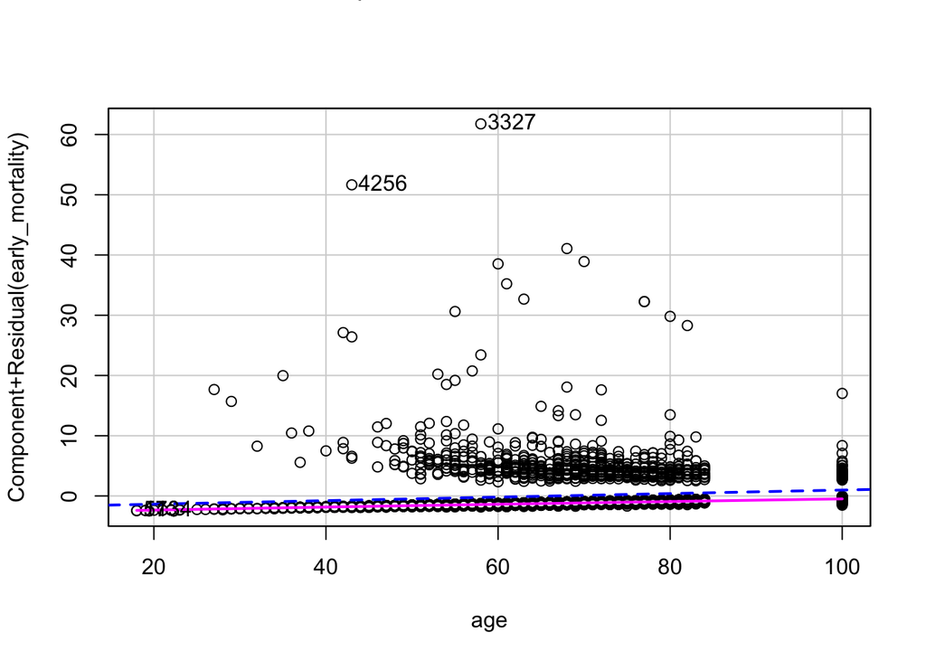

```r
# check for nonlinearity
crPlots(fit2, terms = ~ age, id=T)
```

**Comment:** Age was the only continuous variable in the model. The data follows along with the blue dot line and the association seems to show linearity.

## 14. Leverage and influential points

**Assessing if there are any high leverage or influential points in the model.**

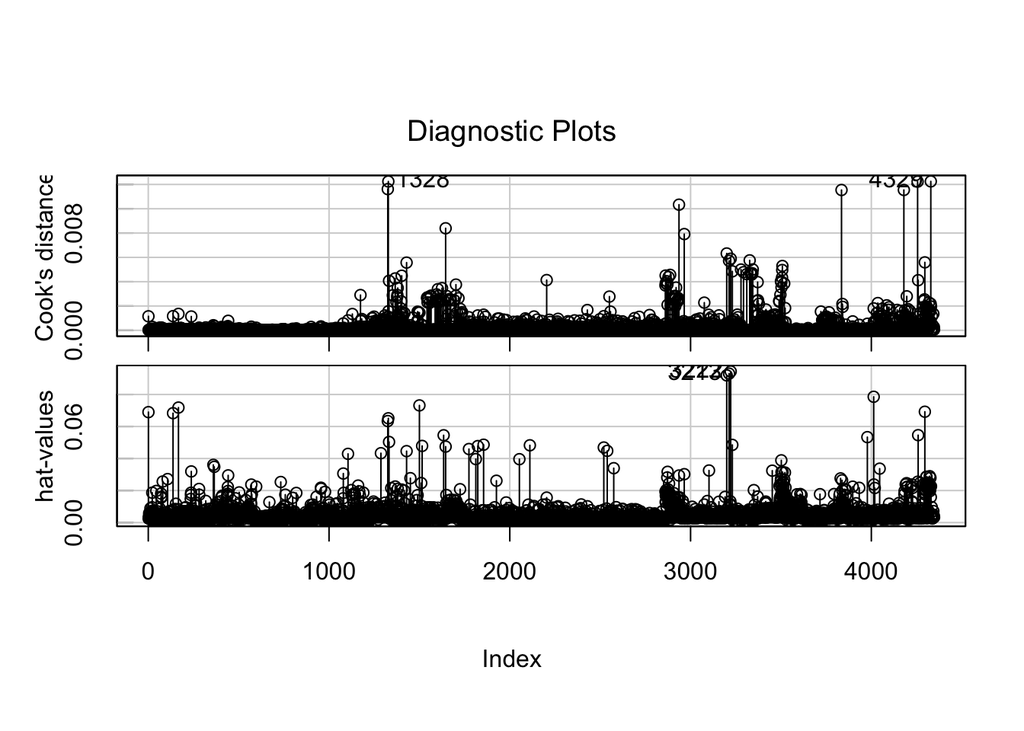

```r
# check metrics of leverage and influence
cook = cooks.distance(fit2)
influenceIndexPlot(fit2, c("Cook","hat"))
```

**Comment:** There seems to be no particularly high leverage or influential points in the model, since the farthest one would only change the fitted values by about 0.01.

## 15. Hosmer-Lemeshow

**Testing if the model appears to fit well to the data.**

```r
# test for goodness of fit
performance::performance_hosmer(fit2)
```

```
## # Hosmer-Lemeshow Goodness-of-Fit Test
##
##   Chi-squared: 6.438
##            df: 8
##       p-value: 0.598
```

```
## Summary: model seems to fit well.
```

**Comment:** The Chi-squared value is small and the p-value is bigger than 0.05. Thus, the model has a good fit.